# coal-maintenance

## Solving a Analytical Problem with Jupyter Notebook

###### Bernard Ade

[figure not shown]

A coal company in Western Australia requires some analytical work. They operate 5 enormous machines that stacks and reclaims mined coals 24-hours/ 365 days. They can't afford to let these machines run idle or else they come up short by millions in revenue.

After meeting with engineers and stakeholders, brainstorming, gathering requirements, a working plan to tackle the problem was conceived.

The challenge is to use the metric **idle capacity** to asesss which of the machines require maintenance. These machines require maintenance when within the **previous month** there was at least one **8-hour period** when the average idle was over **10%**.

The idle capacity metric is defined as follows:

$ Idle\,Capacity = {(Actual\,Tonnes - Nominal\,Capacity) \over Nominal\,Capacity} $

Idle capacity represents unused capacity for the hour. In a nutshell, the tasks requires us to assess if the average of 8 hours exceeds 10% then the machine requires maintenance.

#### Some info about the data:

Datetime - hourly.

Actual Tonnage - utilization per hour.

Nominal Capacity - Nominal capacity for the machine is 4200 tons. Think of nominal as the approximation of accepted conditions.

We will break this process down into 3 steps.

1. Inspect and clean data
2. Compute metric
3. Communicate our results.

I already created this assignment in Tableau. You can check it out [**here**](https://public.tableau.com/profile/knowdata#!/vizhome/Coal_5/Report). Tableau is extremely fast and easy to conduct analysis of this nature. However, working with data in Python is expressive, it helps to build the intuition behind processes whereas in Tableau it all seems like magic.

Lets dive in!

**This post is a re-creation of a mock up assignment of a course taught by Kirill Eremenko titled [Tableau 9 Advanced Training: Master Tableau for Data Science](https://www.udemy.com/tableau-advanced/?LSNPUBID=*JDLXjeE*wk&siteID=.JDLXjeE.wk-St5xoOJ9R6Pvxqt13zgOWg). I highly reccomend this course if you're interested in learning Tableau and solving real life analytical problems.**

### Clean and Inspect data

```python
#import library to structure data
import pandas as pd
# import library to make plots with custom settings
import matplotlib.pyplot as plt
%matplotlib inline
plt.rcParams['figure.figsize'] = (15, 5)
plt.style.use('bmh')
```

```python
# load data into a pandas dataframe, parse the dates and set 'Datetime' as index.
data = pd.read_csv('rl1.csv', parse_dates=True, index_col='Datetime')
```

```python
# inspect table
data.head(3)
```

| Datetime | Nominal Capacity | Actual Tonnes | Unnamed: 3 | Unnamed: 4 | Unnamed: 5 | Unnamed: 6 | Unnamed: 7 | Unnamed: 8 | Unnamed: 9 | Unnamed: 10 | Unnamed: 11 |
| --- | --- | --- | --- | --- | --- | --- | --- | --- | --- | --- | --- |
| 2015-09-01 00:00:00 | 4200 | 4200 | NaN | NaN | NaN | NaN | NaN | NaN | NaN | NaN | NaN |
| 2015-09-01 01:00:00 | 4200 | 3941 | NaN | NaN | NaN | NaN | NaN | NaN | NaN | NaN | NaN |
| 2015-09-01 02:00:00 | 4200 | 3950 | NaN | NaN | NaN | NaN | NaN | NaN | NaN | NaN | NaN |

```python
# 720 rows of data
data.info()
```

```
<class 'pandas.core.frame.DataFrame'>
DatetimeIndex: 720 entries, 2015-09-01 00:00:00 to 2015-09-30 23:00:00
Data columns (total 11 columns):
Nominal Capacity    720 non-null int64
Actual Tonnes       720 non-null int64
Unnamed: 3          0 non-null float64
Unnamed: 4          0 non-null float64
Unnamed: 5          0 non-null float64
Unnamed: 6          0 non-null float64
Unnamed: 7          0 non-null float64
Unnamed: 8          0 non-null float64
Unnamed: 9          0 non-null float64
Unnamed: 10         0 non-null float64
Unnamed: 11         0 non-null float64
dtypes: float64(9), int64(2)
memory usage: 67.5 KB
```

```python
# tactic to keep only the  columns we need.
data = data[['Nominal Capacity', 'Actual Tonnes']]
```

```python
# rename columns for ease of use
data = data.rename(columns={'Nominal Capacity': 'nominal_capacity', 'Actual Tonnes':'actual_tonnes'})
```

```python
# inspect table
data.head()
```

| Datetime | nominal_capacity | actual_tonnes |
| --- | --- | --- |
| 2015-09-01 00:00:00 | 4200 | 4200 |
| 2015-09-01 01:00:00 | 4200 | 3941 |
| 2015-09-01 02:00:00 | 4200 | 3950 |
| 2015-09-01 03:00:00 | 4200 | 4200 |
| 2015-09-01 04:00:00 | 4200 | 4041 |

### Compute Metric

$ Idle\,capacity = {(Actual\,Tonnes - Nominal\,Capacity) \over Nominal\,Capacity} $

```python
# calculate idle capacity metric
data['idle_capacity'] = (data['actual_tonnes'] - data['nominal_capacity'])/data['nominal_capacity']
```

```python
# calculate moving average with a 8-hour window
data['moving_average'] = data.idle_capacity.rolling(window=8,center=False).mean()
```

```python
# inspect the first 15 rows of the table using head function
data.head(15)
```

| Datetime | nominal_capacity | actual_tonnes | idle_capacity | moving_average |
| --- | --- | --- | --- | --- |
| 2015-09-01 00:00:00 | 4200 | 4200 | 0.000000 | NaN |
| 2015-09-01 01:00:00 | 4200 | 3941 | -0.061667 | NaN |
| 2015-09-01 02:00:00 | 4200 | 3950 | -0.059524 | NaN |
| 2015-09-01 03:00:00 | 4200 | 4200 | 0.000000 | NaN |
| 2015-09-01 04:00:00 | 4200 | 4041 | -0.037857 | NaN |
| 2015-09-01 05:00:00 | 4200 | 4200 | 0.000000 | NaN |
| 2015-09-01 06:00:00 | 4200 | 4198 | -0.000476 | NaN |
| 2015-09-01 07:00:00 | 4200 | 4200 | 0.000000 | -0.019940 |
| 2015-09-01 08:00:00 | 4200 | 4199 | -0.000238 | -0.019970 |
| 2015-09-01 09:00:00 | 4200 | 3900 | -0.071429 | -0.021190 |
| 2015-09-01 10:00:00 | 4200 | 4200 | 0.000000 | -0.013750 |
| 2015-09-01 11:00:00 | 4200 | 4018 | -0.043333 | -0.019167 |
| 2015-09-01 12:00:00 | 4200 | 3648 | -0.131429 | -0.030863 |
| 2015-09-01 13:00:00 | 4200 | 4200 | 0.000000 | -0.030863 |
| 2015-09-01 14:00:00 | 4200 | 4100 | -0.023810 | -0.033780 |

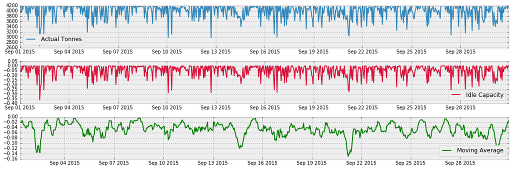

```python
# display plots to gauge the data

plt.subplot(311)
plt.plot(data['actual_tonnes'], label='Actual Tonnes')
plt.legend(loc='best')


plt.subplot(312)
plt.plot(data['idle_capacity'], label='Idle Capacity', color='crimson')
plt.legend(loc='best')

plt.subplot(313)
plt.plot(data['moving_average'],label='Moving Average', color='green')
plt.legend(loc='best')

plt.tight_layout()
```

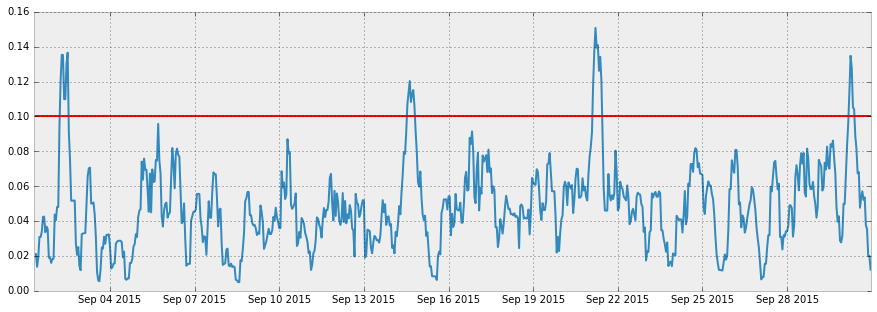

```python
# plot the 8-hour moving average with a 10% reference line. plot looks better if we invert by mulitplying by -1.
plt.plot(data['moving_average'] * -1)
plt.axhline(y=.10, color='r')
plt.show()
```

```python
# filter points that exceeds 10% threshold
spikes = data[data['moving_average']  < -0.10]
```

```python
# display hours that exceeds threshold.
spikes
```

| Datetime | nominal_capacity | actual_tonnes | idle_capacity | moving_average |
| --- | --- | --- | --- | --- |
| 2015-09-02 06:00:00 | 4200 | 3292 | -0.216190 | -0.120625 |
| 2015-09-02 07:00:00 | 4200 | 3337 | -0.205476 | -0.135387 |
| 2015-09-02 08:00:00 | 4200 | 4199 | -0.000238 | -0.135208 |
| 2015-09-02 09:00:00 | 4200 | 4200 | 0.000000 | -0.109881 |
| 2015-09-02 10:00:00 | 4200 | 4200 | 0.000000 | -0.109881 |
| 2015-09-02 11:00:00 | 4200 | 3131 | -0.254524 | -0.130089 |
| 2015-09-02 12:00:00 | 4200 | 3982 | -0.051905 | -0.136577 |
| 2015-09-14 13:00:00 | 4200 | 3402 | -0.190000 | -0.107083 |
| 2015-09-14 14:00:00 | 4200 | 3632 | -0.135238 | -0.114018 |
| 2015-09-14 15:00:00 | 4200 | 3753 | -0.106429 | -0.120298 |
| 2015-09-14 16:00:00 | 4200 | 4118 | -0.019524 | -0.108244 |
| 2015-09-14 17:00:00 | 4200 | 3650 | -0.130952 | -0.112917 |
| 2015-09-14 18:00:00 | 4200 | 3674 | -0.125238 | -0.115119 |
| 2015-09-14 19:00:00 | 4200 | 4098 | -0.024286 | -0.105952 |
| 2015-09-21 03:00:00 | 4200 | 3137 | -0.253095 | -0.118690 |
| 2015-09-21 04:00:00 | 4200 | 3049 | -0.274048 | -0.137411 |
| 2015-09-21 05:00:00 | 4200 | 3751 | -0.106905 | -0.150774 |
| 2015-09-21 06:00:00 | 4200 | 4200 | 0.000000 | -0.139315 |
| 2015-09-21 07:00:00 | 4200 | 3643 | -0.132619 | -0.140923 |
| 2015-09-21 08:00:00 | 4200 | 4164 | -0.008571 | -0.126161 |
| 2015-09-21 09:00:00 | 4200 | 3562 | -0.151905 | -0.134167 |
| 2015-09-21 10:00:00 | 4200 | 4028 | -0.040952 | -0.121012 |
| 2015-09-30 05:00:00 | 4200 | 3589 | -0.145476 | -0.114345 |
| 2015-09-30 06:00:00 | 4200 | 3514 | -0.163333 | -0.134762 |
| 2015-09-30 07:00:00 | 4200 | 4131 | -0.016429 | -0.127649 |
| 2015-09-30 08:00:00 | 4200 | 4200 | 0.000000 | -0.105208 |
| 2015-09-30 09:00:00 | 4200 | 3979 | -0.052619 | -0.104196 |

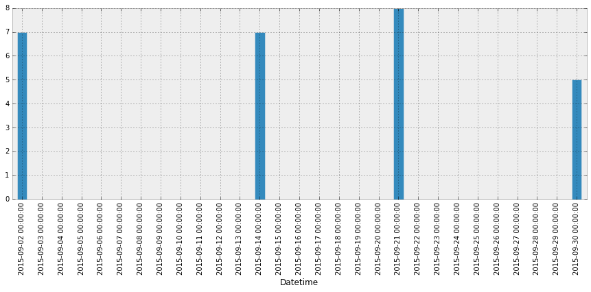

```python
# plot days that exceed the 10% threshold.
spikes.moving_average.resample('D').count().plot(kind='bar', )
```

### Report

Our findings illustrates the 8-hour moving average of idle capacity for Reclaimer 1 expresed as a percentage of nominal capacity.

Throughout the month RL1 exceeded the allowable threshold multiple times:

Rolling average peaked @ 14% on 9-02-2015

Rolling average peaked @ 12% on 9-14-2015

Rolling average peaked @ 15% on 9-21-2015

It is evident that this machine requires maintenance in the upcoming month.